# Investigating Suicide Rates Overview 1985 to 2016.

In this analysis I will be focusing at investigating factors that could influence suicide rates among different user cohorts and countries.

The dataset includes info on suicide rates among different cohorts together with the country, region and country economical status. This compiled dataset pulled from four other datasets linked by time and place, and was built to find signals correlated to increased suicide rates among different cohorts globally, across the socio-economic spectrum.

### Main subject for analysis

In this analysis my primary focus is to investigate factors that could possibly influence suicide rates, as well as to get some insight on suicide rates among different generations and genders, as well as to discover some general trends.

To do this, at first I will investigate the most recent data on suicide rates among different countries to discover possible patterns, and later will focus on trends comparison of suicide rates per 100k population within different generations and gender.

The primary focus for the analysis will be around universal suicide ratio of the number of suicides per 100k population.

This metric is taken as a centralised object of analysis as it is independent from population size and therefore will be more objective in representing general trends.

In total, there's a range of observations for 101 country for the period of 31 years, which is really impressive.

The world's average suicides per 100k population across 31 year would be sitting somewhere within 10 suicides per 100k population. Overall, the dataset is heavily skewed to the right having non-normal distribution.

Together, after the investigation we can categorize outliers as countries having > 6000 suicides per year or over 31 suicide cases per 100k population. Let's review those in details.

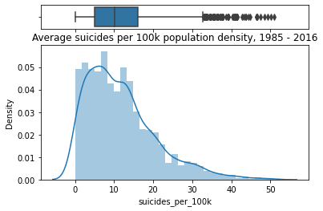

```python
#density plot
# Cut the window in 2 parts
f, (ax_box, ax_hist) = plt.subplots(2, sharex=True, gridspec_kw={"height_ratios": (.15, .85)});
# Add a graph in each part
sns.boxplot(df_country["suicides_per_100k"], ax=ax_box);
sns.distplot(df_country["suicides_per_100k"], ax=ax_hist);
plt.title('Average suicides per 100k population density, 1985 - 2016');
# Remove x axis name for the boxplot
ax_box.set(xlabel='');
```

### Worldwide suicide rate - average view

As we can see from here, the average worldwide suicide rates been climbing up constantly to reach peak between 1195 to 1997, followed by a gradual decrease in rates until 2015. However, after they spiked again in 2016!

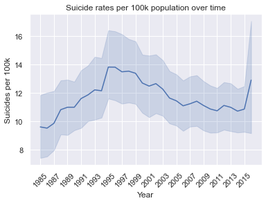

```python
#look at how mean suicide rates been changing over time
sns.set_theme(style='darkgrid')
ax = sns.lineplot(x = 'year', y='suicides_per_100k', data = df_fin);
ax.set(xlabel = 'Year', ylabel = 'Suicides per 100k');
plt.title('Suicide rates per 100k population over time');
plt.xticks(np.arange(1985,2016, step = 2), rotation = 45);
```

### Correlation of suicide rates per 100k vs. other factors

Based on the correlation matrix, there is nothing we can strongly associate with the plot.

A few mild/strong positive correlation points were discovered based between time variable and human development index, as well as GDP growth (good news). However, it is interesting to observe only a slight/weak correlation between gdp per capita and country gdp. That means that it is unlikely that if the country is producing more GDP, its households will get much richer.

Let's have a look into what's going on within the ratio of countries with different suicide rates over time.

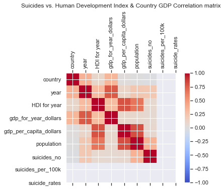

```python
#correlation matrix
corr = df_fin.corr()
fig = plt.figure()
ax = fig.add_subplot(111)
cax = ax.matshow(corr,cmap='coolwarm', vmin=-1, vmax=1)
fig.colorbar(cax)
ticks = np.arange(0,len(df_fin.columns),1)
ax.set_xticks(ticks)
plt.xticks(rotation=90)
ax.set_yticks(ticks)
ax.set_xticklabels(df_fin.columns)
ax.set_yticklabels(df_fin.columns)
plt.title('Suicides vs. Human Development Index & Country GDP Correlation matrix');
plt.show()
```

We can see from the chart, that period 1996-2001 there was way higher number of countries with high suicide rates. As the world moves on, more countries are shifting from extreme cohorts towards lower cohort.

However, in the meantime, extra-low segment shows almost no improvement at all, what can set good targets in the future.

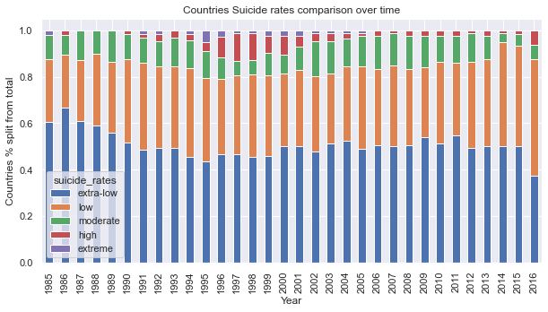

```python
df_suicide = df_fin.groupby(['year','suicide_rates'])['country'].count().reset_index()
df_suicide = df_suicide.pivot(index = 'year', columns = 'suicide_rates', values = 'country')
df_suicide = df_suicide.div(df_suicide.sum(axis=1),axis=0);
sr = df_suicide.plot.bar(stacked = True, figsize = (10,5));
sr.set(xlabel = 'Year', ylabel = 'Countries % split from total');
plt.title('Countries Suicide rates comparison over time');
```

##### Men tend to commit suicide more often, than women.

First of all, males tend to be more vulnerable group than females, as their suicide rates per 100k population is many times higher than females. That pattern is observed among all age groups, and observed consistently over the course of the given time period from 1985 to 2015.

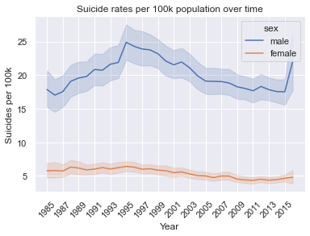

```python
sns.set_theme(style='darkgrid')
ax = sns.lineplot(x = 'year', y='suicidesper100kpop', hue = 'sex', data = df);
ax.set(xlabel = 'Year', ylabel = 'Suicides per 100k');
plt.title('Suicide rates per 100k population over time');
plt.xticks(np.arange(1985,2016, step = 2), rotation = 45);
```

#### WWII Generation reported highest suicide rates than everyone else

Based on the chart, G.I. Generation as well as Silent one tend to have the highest suicide rates per history.

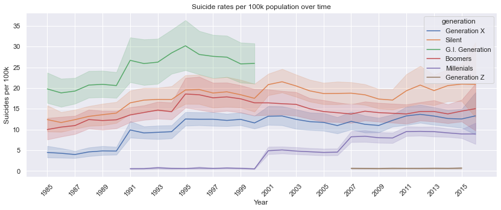

```python
sns.set_theme(style='darkgrid')
fig, ax = plt.subplots(figsize=(14,5))
ax = sns.lineplot(x = 'year', y='suicidesper100kpop', hue = 'generation', data = df);
ax.set(xlabel = 'Year', ylabel = 'Suicides per 100k');
plt.title('Suicide rates per 100k population over time');
plt.xticks(np.arange(1985,2016, step = 2), rotation = 45);
```

#### Higher suicide rate for G.I. Generation is similar across both females and males.

Based on the chart, the trend is similar across both males and females.

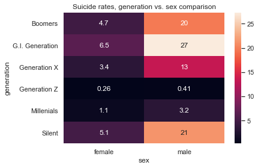

```python
suicide_per_generation = df.pivot_table(values='suicidesper100kpop', index = 'generation', columns = 'sex', aggfunc = np.median)
sns.heatmap(suicide_per_generation, annot = True);
plt.title('Suicide rates, generation vs. sex comparison');
plt.show()
```

##### The older the person, the higher the suicide rate is.

It is alarming considering that planet population is getting older in general.

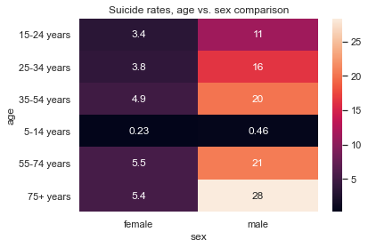

```python
suicide_per_gender = df.pivot_table(values='suicidesper100kpop', index = 'age', columns = 'sex', aggfunc = np.median)
sns.heatmap(suicide_per_gender, annot = True);
plt.title('Suicide rates, age vs. sex comparison');
plt.show()
```

##### Almost all countries with high and extreme suicide rates are sitting within countries with low GDP and GDP per capita.

After additional segmentation it was discovered that pretty much all countries with high and extreme suicide rates per 100k population are coming from countries with low GDP & GDP per capita. Therefore, less lucky countries that are more economically vulnerable are prone to population suicide.

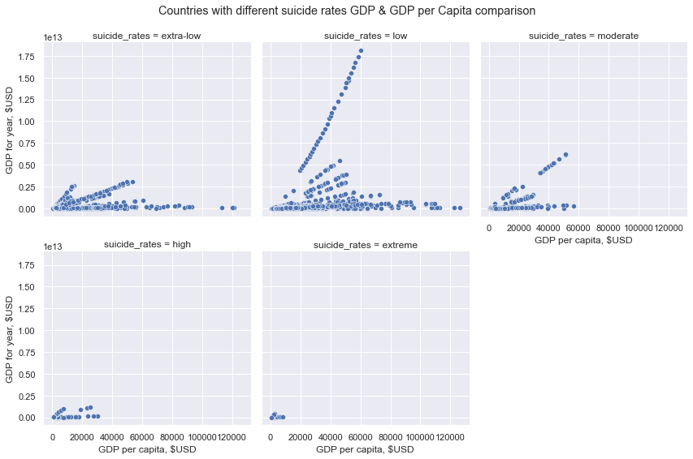

```python
g = sns.FacetGrid(df_fin, col = 'suicide_rates',height=4, aspect= 1, col_wrap = 3);
g.map(sns.scatterplot,'gdp_per_capita_dollars', 'gdp_for_year_dollars');
g.set_axis_labels('GDP per capita, $USD', 'GDP for year, $USD');
plt.subplots_adjust(top=0.9)
g.fig.suptitle('Countries with different suicide rates GDP & GDP per Capita comparison');
```

### Conclusion

During the analysis, a few interesting dependancies were discovered.

##### Men tend to commit suicide more often, than women.

First of all, males tend to be more vulnerable group than females, as their suicide rates per 100k population is many times higher than females. That pattern is observed among all age groups, and observed consistently over the course of the given time period from 1985 to 2015.

##### The older the person, the higher the suicide rate is.

It is alarming considering that planet population is getting older in general.

##### Almost all countries with high and extreme suicide rates are sitting within countries with low GDP and GDP per capita.

After additional segmentation it was discovered that pretty much all countries with high and extreme suicide rates per 100k population are coming from countries with low GDP & GDP per capita. Therefore, less lucky countries that are more economically vulnerable are prone to population suicide.